# Part II - (Exploring factors of Prosper Loan Data)

## By (OLUSOLA SAMSON)

## Investigation Overview

**I wanna know about:**

> **The factors surrounding collection of loans and how much the lenders make?**

> **Does creditscore really affect loan payments or is it just a ruse ?**

## Dataset Overview

> **There are 77557 loans and 17 variables with of which most are numerical in nature and the rest are dates and categorical data. most variables e.g credit score are ordered/ranked, while Term and Loan status are categorical**

## (Distribution of Loan OriginalAmount )

**With the removal of the outliers,we can see that most proportion of people collected loans ranging from \$1,000 to\\$25,000 , which peaked at around \$4,000, coming in second is \\$15,000 and third \$10,000. In depth , we can see that most loans collected ranges from a $1000 to \$10,000.**

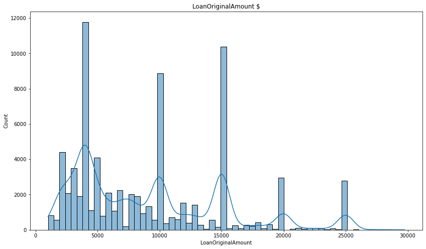

## (Distribution of the Loan Status)

**The Chart below shows that most loans are still in the current phase ,with those completed coming next to it,and those charged off coming in third. The rest of the observations coming in the similar ranges.**

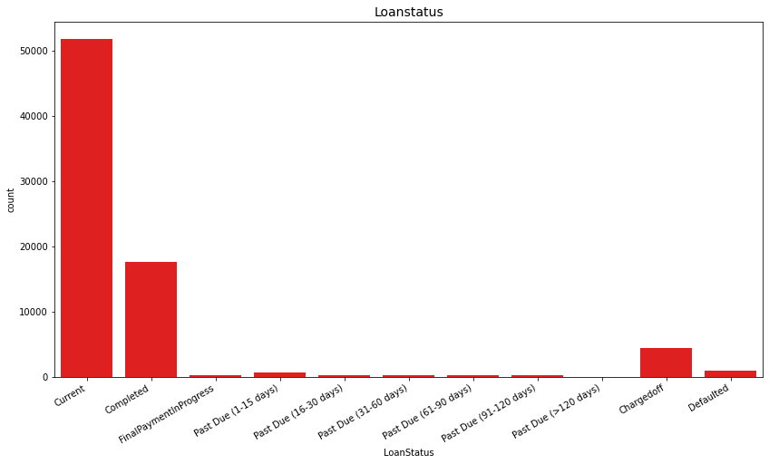

## (Distribution of intrest rates)

**As illustrated above a higher section of people's BorrowerAPR falls between 10 to 40% and a lower section go below that . In the case of the BorrowerRate a higher percent falls between the 10 to 30% range while the rest are below or higher than that. While for LenderYield a fairly decent amount fall between 0 to 10% while most fall between 10 to 30% and the rest belong to a smaller demographic Finally, for EstimatedEffectiveYield like previous analysis most fall between the 10 to 30% range and few fall between 0 to 10% while little or nothing fall between 30 to 40%**

[figure not shown]

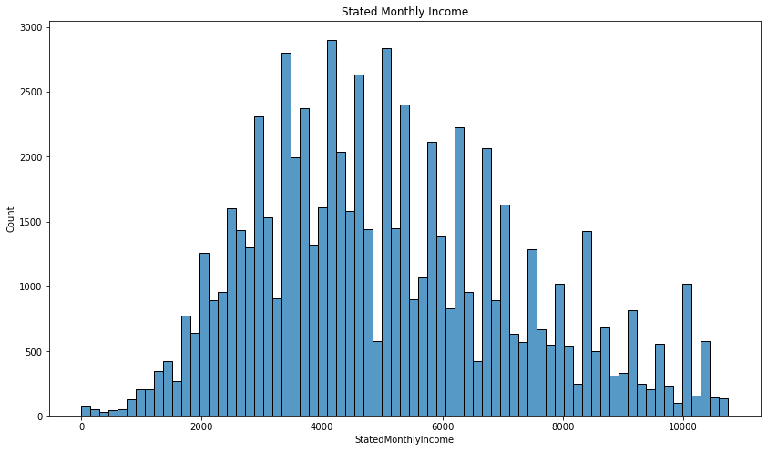

## (Creditscore vs Creditscore Rating)

[figure not shown]

## (Creditscore vs Loan Status)

**There seems to be a high distribution of loans that are current which dominates most of the data, with those chargedoff,defaulted and completed having a decent distribution amongst the data, while those past due coming up very few. since 'Excellent:800-850' 'Very good:740-799', 'Good: 670-739', 'Fair: 580-669', 'Poor: 300-579' most people have a creditscore which are good,fair and very good.**

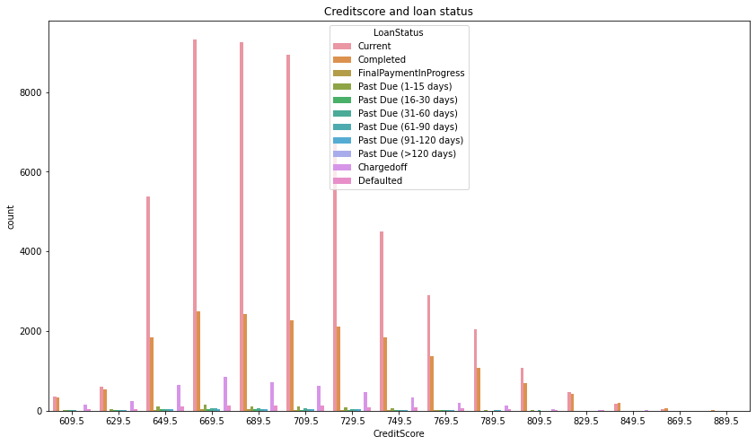

## (Distribution of LoanOriginalAmount and StatedMonthlyIncome by LoanStatus and CreditScore Rating

The amount of loans still ongoing are more than expected , people with very good or fair rating dominating the current loan status, the range of money they make about 4000 to 8000 collecting loans up to 25,0000 which is suprising considering the fact that they earn more and have a stable income.

Then we have the completed loans, the loans which have been fully paid have a creditscore of either very good or fair , people with the upper range of income occuring more in the observation , i had a conception thought the completed loans will have been dominated by people with excellent and very good creditscore rating .

Moving on ,we go on to the losses the defaulted and chargedoff loans. These are the loans which have been given up , now lets see the people involved.

The lower range of loans collected have a higher distribution of fair rating (i.e those with the smaller loans are mostly fair which is understandable) but not so much suprising again, is that the remaining creditscore rating including excellent also have a decent distribution in the loans that are defaulted and chargedoff.

The loans that are past due are more of what we've been expecting with most coming in at good and fair, with few very-good and excellent.

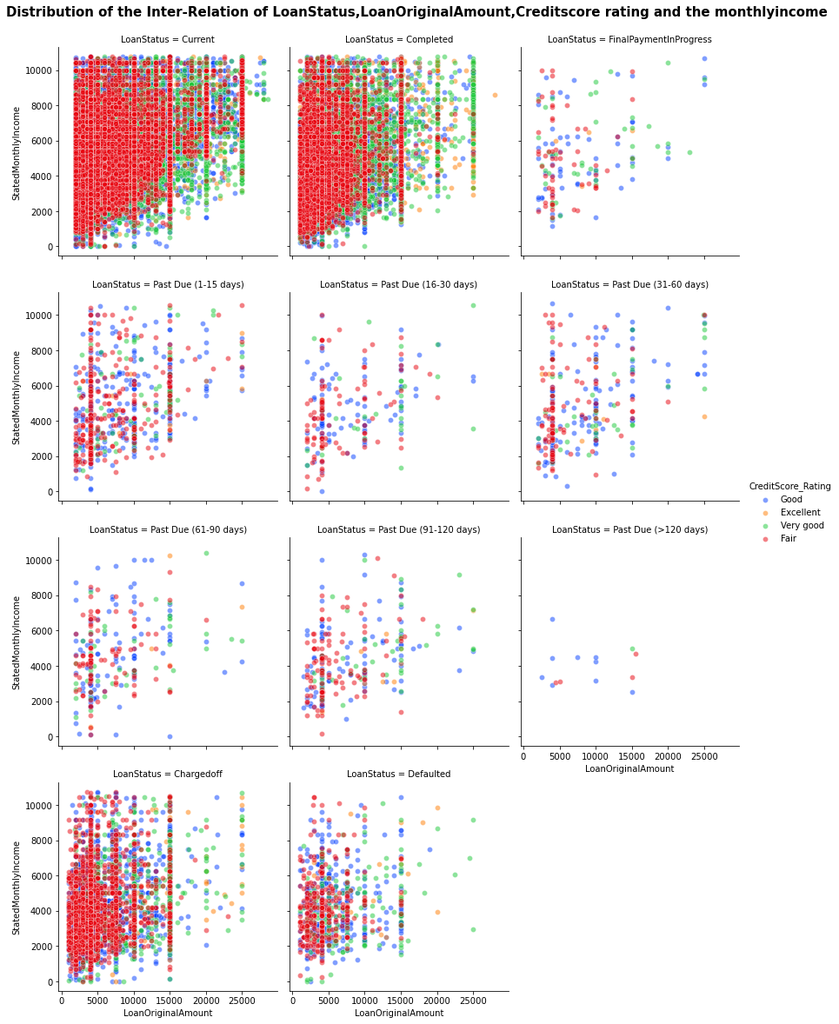

## (Intrest Rates vs LoanStatus )

The Annual Percentage Rate (APR) for the loan go up to 40% which is a lot for 1 loan.

The interest rate for this loan go up to 35% of the original loan.

The Lender yield which is equal to the interest rate on the loan less the servicing fee also go up to 35%.

Effective yield is equal to the borrower interest rate (i) minus the servicing fee rate, (ii) minus estimated uncollected interest on charge-offs, (iii) plus estimated collected late fees go up to 30%.

Estimated return is the difference between the Estimated Effective Yield and the Estimated Loss Rate: which is the money expeceted to gain even after the loss go up to 25%

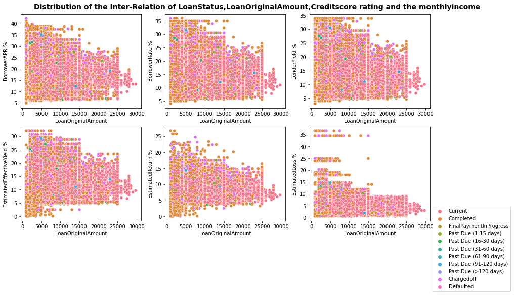